The analysis and prediction This analysis tries to understand the relationship between different factors and their influence on medical charges. Machine learning models are then developed to predic charges based on the expaliner facorts in the data

```python
import pandas as pd
import numpy as np
import matplotlib.pyplot as plt
import seaborn as sns
sns.set_theme(color_codes=True)
import warnings
warnings.filterwarnings("ignore")
%matplotlib inline
```

```python
#Loading the dataset
data=pd.read_csv("Medical Const Data.csv")
```

# Exploratory Data Analysis

### Undderstanding the data

```python
#dropping unwanted columns
data.drop(["Unnamed: 7","Unnamed: 8","Unnamed: 9"],axis=1,inplace=True)
```

```python
print("data head")
print(data.head())
print("")
print("data tail")
print(data.tail())
print("")
print("data info")
print(data.info())
print("")
print("data described")
print(data.describe())
print("")
print(f"data shape: {data.shape}")
print("")
print("data types")
print(data.dtypes)
```

```
data head
   age     sex     bmi  children smoker     region      charges
0   19  female  27.900         0    yes  southwest  16884.92400
1   18    male  33.770         1     no  southeast   1725.55230
2   28    male  33.000         3     no  southeast   4449.46200
3   33    male  22.705         0     no  northwest  21984.47061
4   32    male  28.880         0     no  northwest   3866.85520

data tail
      age     sex    bmi  children smoker     region     charges
1333   50    male  30.97         3     no  northwest  10600.5483
1334   18  female  31.92         0     no  northeast   2205.9808
1335   18  female  36.85         0     no  southeast   1629.8335
1336   21  female  25.80         0     no  southwest   2007.9450
1337   61  female  29.07         0    yes  northwest  29141.3603

data info
<class 'pandas.core.frame.DataFrame'>
RangeIndex: 1338 entries, 0 to 1337
Data columns (total 7 columns):
 #   Column    Non-Null Count  Dtype
---  ------    --------------  -----
 0   age       1338 non-null   int64
 1   sex       1338 non-null   object
 2   bmi       1338 non-null   float64
 3   children  1338 non-null   int64
 4   smoker    1338 non-null   object
 5   region    1338 non-null   object
 6   charges   1338 non-null   float64
dtypes: float64(2), int64(2), object(3)
memory usage: 73.3+ KB
None

data described
               age          bmi     children       charges
count  1338.000000  1338.000000  1338.000000   1338.000000
mean     39.207025    30.663397     1.094918  13270.422265
std      14.049960     6.098187     1.205493  12110.011237
min      18.000000    15.960000     0.000000   1121.873900
25%      27.000000    26.296250     0.000000   4740.287150
50%      39.000000    30.400000     1.000000   9382.033000
75%      51.000000    34.693750     2.000000  16639.912515
max      64.000000    53.130000     5.000000  63770.428010

data shape: (1338, 7)

data types
age           int64
sex          object
bmi         float64
children      int64
smoker       object
region       object
charges     float64
dtype: object
```

```python
#Checking Null vallues
data.isnull().sum()
```

```
age         0
sex         0
bmi         0
children    0
smoker      0
region      0
charges     0
dtype: int64
```

```python
#Finding duplicates
data.duplicated().sum()
```

```
1
```

```python
#dropping duplicates
data.drop_duplicates(inplace=True)
```

```python
#Confirming no more Duplicates
data.duplicated().sum()
```

```
0
```

```python
data.select_dtypes(include="object").nunique()
```

```
sex       2
smoker    2
region    4
dtype: int64
```

```python
#Selecting categorical data
data.select_dtypes(include="object")
```

|  | sex | smoker | region |
| --- | --- | --- | --- |
| 0 | female | yes | southwest |
| 1 | male | no | southeast |
| 2 | male | no | southeast |
| 3 | male | no | northwest |
| 4 | male | no | northwest |
| ... | ... | ... | ... |
| 1333 | male | no | northwest |
| 1334 | female | no | northeast |
| 1335 | female | no | southeast |
| 1336 | female | no | southwest |
| 1337 | female | yes | northwest |

## Univariate Analysis

### Distribution of Categorical Variables

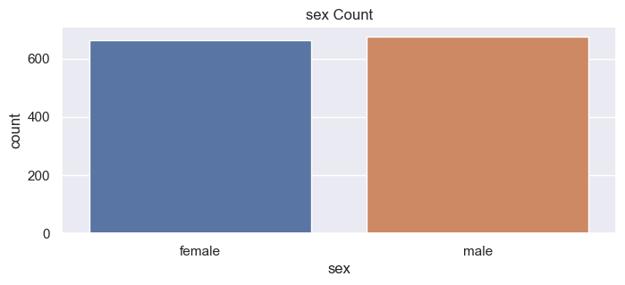

```python
    plt.figure(figsize=(8,3))
    plt.title("sex Count")
    sns.countplot(x="sex",data=data)
    plt.show()
```

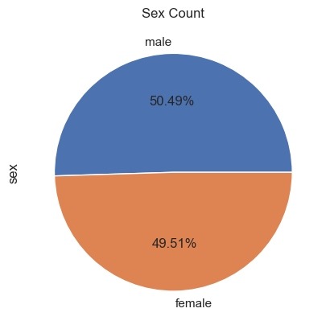

```python
data["sex"].value_counts().plot(kind="pie",autopct="%.2f%%")
plt.title("Sex Count")
plt.show()
```

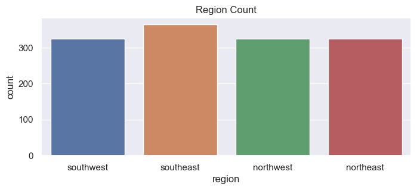

```python
    plt.figure(figsize=(8,3))
    plt.title("Region Count")
    sns.countplot(x="region",data=data)
    plt.show()
```

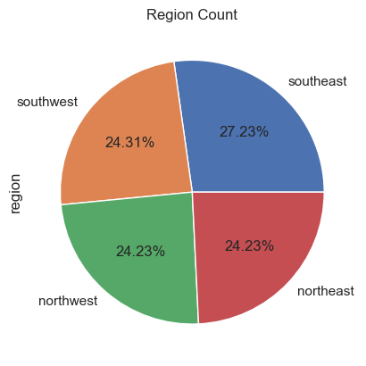

```python
data["region"].value_counts().plot(kind="pie",autopct="%.2f%%")
plt.title("Region Count")
plt.show()
```

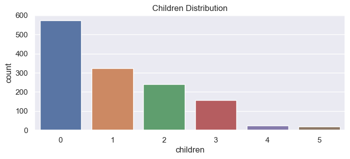

```python
    plt.figure(figsize=(8,3))
    plt.title("Children Distribution")
    sns.countplot(x="children",data=data)
    plt.show()
```

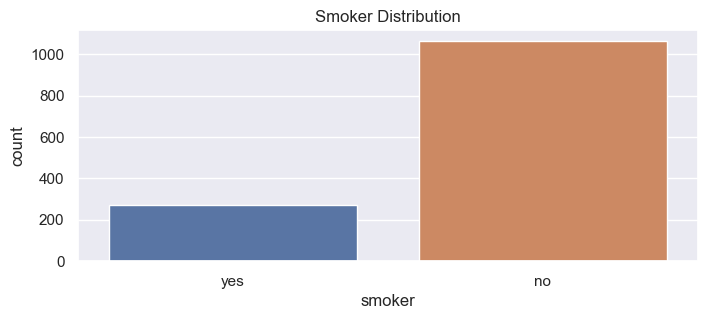

```python
    plt.figure(figsize=(8,3))
    plt.title("Smoker Distribution")
    sns.countplot(x="smoker",data=data)
    plt.show()
```

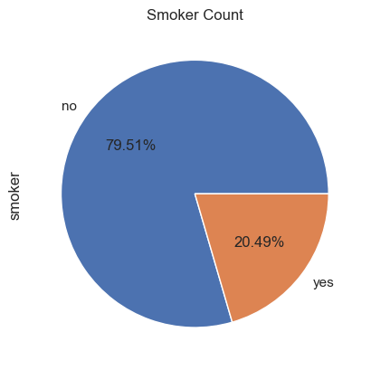

```python
data["smoker"].value_counts().plot(kind="pie",autopct="%.2f%%")
plt.title("Smoker Count")
plt.show()
```

#### Segmenting age into age groups

Dividing age into classes of age ranges to analyse any hidden trends of for each age class.

```python
data["age"].unique()
```

```
array([19, 18, 28, 33, 32, 31, 46, 37, 60, 25, 62, 23, 56, 27, 52, 30, 34,
       59, 63, 55, 22, 26, 35, 24, 41, 38, 36, 21, 48, 40, 58, 53, 43, 64,
       20, 61, 44, 57, 29, 45, 54, 49, 47, 51, 42, 50, 39], dtype=int64)
```

```python
#Age Description
print(f"max age; {data.age.max()}")
print(f"min age; {data.age.min()}")
print(f"median age; {data.age.median()}")
print(f"mean age; {data.age.mean()}")
```

```
max age; 64
min age; 18
median age; 39.0
mean age; 39.222139117427076
```

```python
#Creating a function for age group
def age_group(age):
    #Defining Age groups
    if (age>=18 and age<=35):
        return "youth"
    if (age>=36 and age<=50):
        return "mid_age"
    else:
        return "senior_age"
data["age_group"]=data["age"].apply(age_group)
```

```python
#Head for new data
data.head()
```

|  | age | sex | bmi | children | smoker | region | charges | age_group |
| --- | --- | --- | --- | --- | --- | --- | --- | --- |
| 0 | 19 | female | 27.900 | 0 | yes | southwest | 16884.92400 | youth |
| 1 | 18 | male | 33.770 | 1 | no | southeast | 1725.55230 | youth |
| 2 | 28 | male | 33.000 | 3 | no | southeast | 4449.46200 | youth |
| 3 | 33 | male | 22.705 | 0 | no | northwest | 21984.47061 | youth |
| 4 | 32 | male | 28.880 | 0 | no | northwest | 3866.85520 | youth |

```python
#Check data type of new column
data.age_group.dtypes
```

```
dtype('O')
```

```python
data.age_group.value_counts()
```

```
youth         573
mid_age       408
senior_age    356
Name: age_group, dtype: int64
```

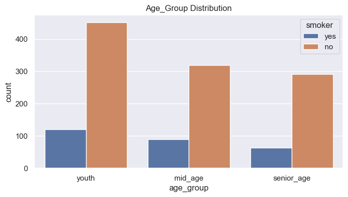

```python
    plt.figure(figsize=(8,4))
    plt.title("Age_Group Distribution")
    sns.countplot(x= "age_group",data=data,hue="smoker")
    plt.show()
```

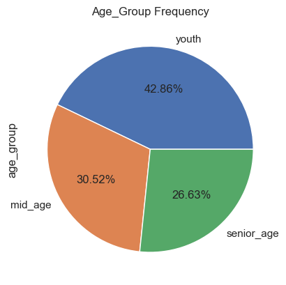

```python
data["age_group"].value_counts().plot(kind="pie",autopct="%.2f%%")
plt.title("Age_Group Frequency")
plt.show()
```

### Distribution Of Numerical Variables

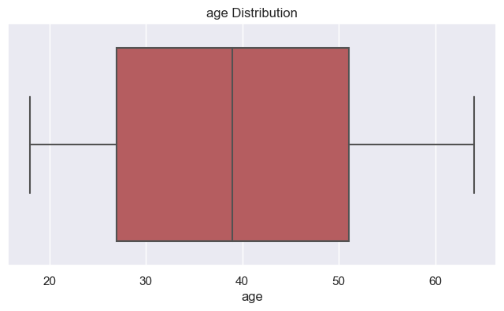

```python
    plt.figure(figsize=(8,4))
    plt.title("age Distribution")
    sns.boxplot(x="age",data=data,color="r")
    plt.show()
```

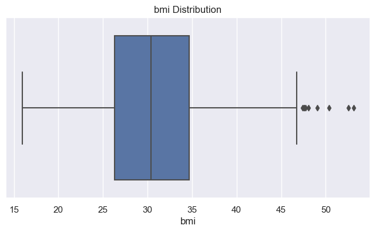

```python
    plt.figure(figsize=(8,4))
    plt.title("bmi Distribution")
    sns.boxplot(x="bmi",data=data)
    plt.show()
```

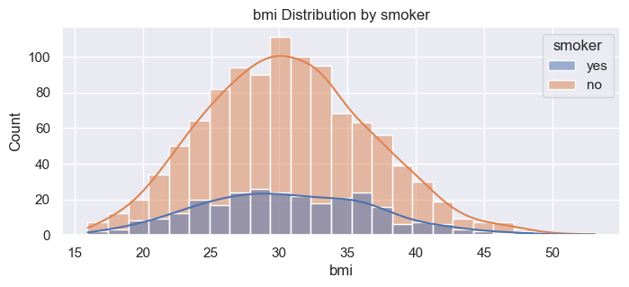

```python
    plt.figure(figsize=(8,3))
    plt.title("bmi Distribution by smoker")
    sns.histplot(x="bmi",data=data,kde=True,hue="smoker")
    plt.show()
```

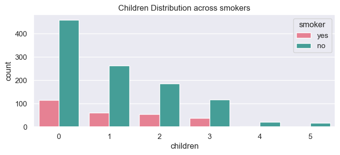

```python
    plt.figure(figsize=(8,3))
    plt.title("Children Distribution across smokers")
    sns.countplot(x="children",data=data,hue="smoker",palette="husl")
    plt.show()
```

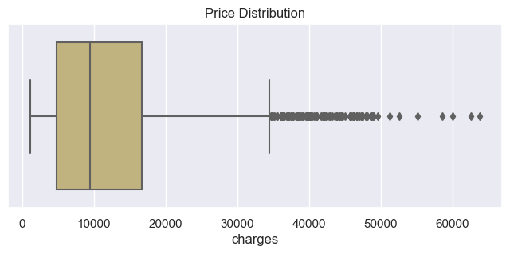

```python
    plt.figure(figsize=(8,3))
    plt.title("Price Distribution")
    sns.boxplot(x="charges",data=data,color="y")
    plt.show()
```

### Multivariate analysis

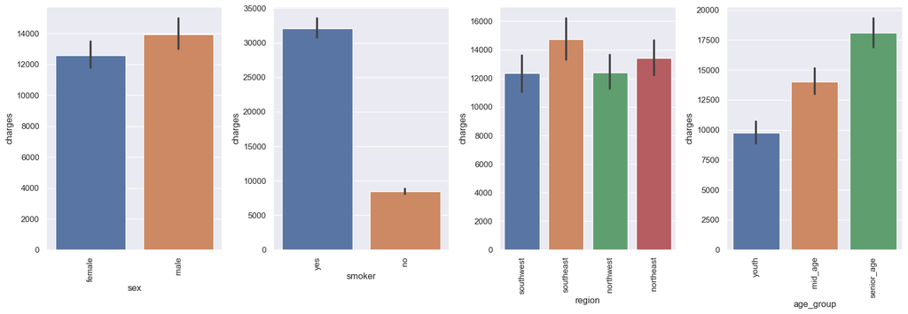

```python
Categorical_Vallues=["sex","smoker","region","age_group"]

fig, axs =plt.subplots(nrows=1, ncols=4, figsize=(17,6))

axs=axs.flatten()
for i,var in enumerate(Categorical_Vallues):
    sns.barplot(x=var,y="charges",data=data,ax=axs[i])
    axs[i].set_xticklabels(axs[i].get_xticklabels(),rotation=90)

fig.tight_layout()
plt.show()
```

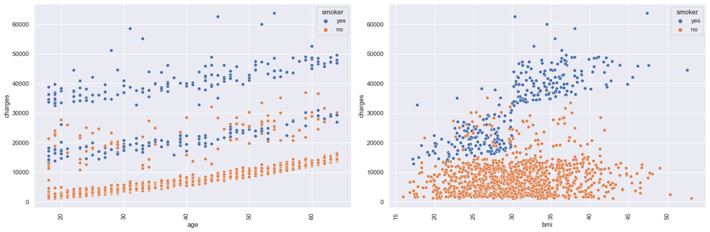

```python
Numeric_Vallues=["age","bmi"]


fig, axs =plt.subplots(nrows=1, ncols=2, figsize=(18,6))

axs=axs.flatten()
for i,var in enumerate(Numeric_Vallues):
    sns.scatterplot(x=var,y="charges",data=data,ax=axs[i],hue="smoker")
    axs[i].set_xticklabels(axs[i].get_xticklabels(),rotation=90)

fig.tight_layout()
plt.show()
```

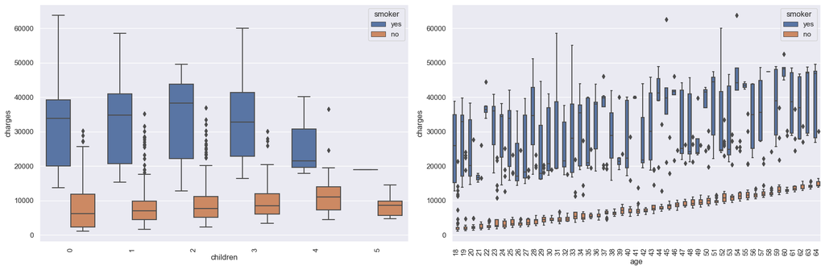

```python
Numeric_Vallues=["children","age"]


fig, axs =plt.subplots(nrows=1, ncols=2, figsize=(18,6))

axs=axs.flatten()
for i,var in enumerate(Numeric_Vallues):
    sns.set_style("darkgrid")
    sns.boxplot(x=var,y="charges",data=data,ax=axs[i],hue="smoker")
    axs[i].set_xticklabels(axs[i].get_xticklabels(),rotation=90)

fig.tight_layout()
plt.show()
```

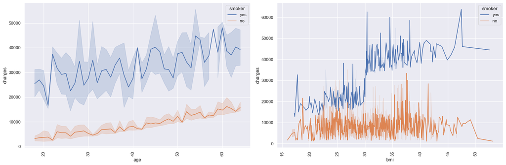

```python
Numeric_Vallues=["age","bmi"]


fig, axs =plt.subplots(nrows=1, ncols=2, figsize=(18,6))

axs=axs.flatten()
for i,var in enumerate(Numeric_Vallues):
    sns.lineplot(x=var,y="charges",data=data,ax=axs[i],hue="smoker")
    axs[i].set_xticklabels(axs[i].get_xticklabels(),rotation=90)

fig.tight_layout()
plt.show()
```

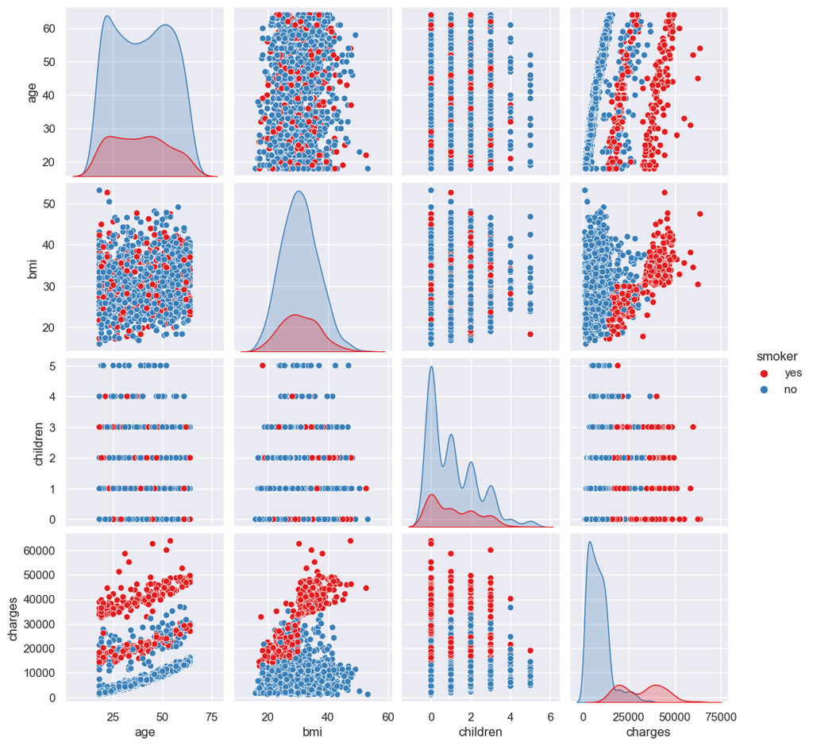

```python
#Pairplot to show each variable against another
sns.pairplot(data,hue="smoker",palette="Set1")
sns.set_style("darkgrid")
plt.show()
```

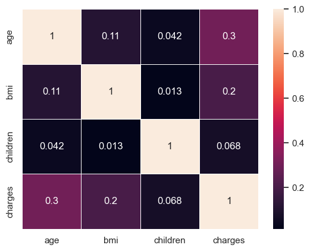

```python
#heatmap to show correlation betrween numeric variables
sns.heatmap(data.corr(),cbar=True,linewidth=0.5,annot=True)
plt.show()
```

## Data Processing 2

#### Handling Outliers

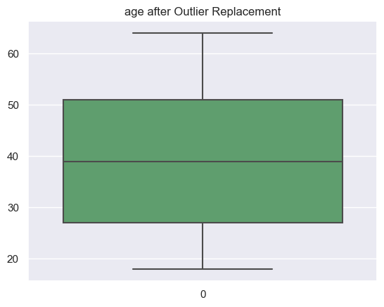

```python
#replacing outliers with median in age using IQR
for i in data["age"]:
    q1=data["age"].quantile(0.25)
    q3=data["age"].quantile(0.75)
    iqr=q3-q1
    lower=q1-1.5*iqr
    upper=q3+1.5*iqr
    if i>upper or i<lower:
        data2["age"]=data["age"].replace(i,np.median(data["age"]))
figure =figsize=(8,3)
plt.title("age after Outlier Replacement")
sns.boxplot(data["age"],color="g")
plt.show()
```

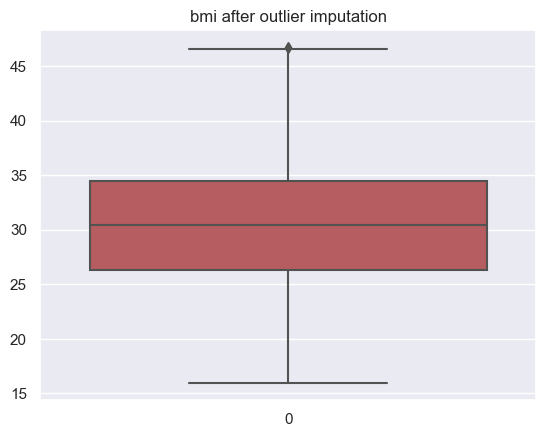

```python
for i in data["bmi"]:
    q1=data["bmi"].quantile(0.25)
    q3=data["bmi"].quantile(0.75)
    iqr=q3-q1
    lower=q1-1.5*iqr
    upper=q3+1.5*iqr
    if i>upper or i<lower:
        data["bmi"]=data["bmi"].replace(i,np.median(data["bmi"]))
figure=figsize=(8,4)
plt.title("bmi after outlier imputation")
sns.boxplot(data["bmi"],color="r")
plt.show()
```

### Label Encoding Categorical Variables

Encoding is done for categorical variables for transform them into intagers

```python
for col in data.select_dtypes(include=["object"]).columns:
    print(f"{col}: {data[col].unique()}")
```

```
sex: ['female' 'male']
smoker: ['yes' 'no']
region: ['southwest' 'southeast' 'northwest' 'northeast']
age_group: ['youth' 'mid_age' 'senior_age']
```

```python
from sklearn import preprocessing
for col in data.select_dtypes(include=["object"]).columns:
    le=preprocessing.LabelEncoder()
    le.fit(data[col].unique())
    data[col]=le.transform(data[col])
```

```python
data.head()
```

|  | age | sex | bmi | children | smoker | region | charges | age_group |
| --- | --- | --- | --- | --- | --- | --- | --- | --- |
| 0 | 19 | 0 | 27.900 | 0 | 1 | 3 | 16884.92400 | 2 |
| 1 | 18 | 1 | 33.770 | 1 | 0 | 2 | 1725.55230 | 2 |
| 2 | 28 | 1 | 33.000 | 3 | 0 | 2 | 4449.46200 | 2 |
| 3 | 33 | 1 | 22.705 | 0 | 0 | 1 | 21984.47061 | 2 |
| 4 | 32 | 1 | 28.880 | 0 | 0 | 1 | 3866.85520 | 2 |

```python
#
print(f"Encoded sex: {data.sex.unique()}")
print(f"Encoded smoker: {data.smoker.unique()}")
print(f"Encoded region: {data.region.unique()}")
print(f"Encoded age_group: {data.age_group.unique()}")
```

```
Encoded sex: [0 1]
Encoded smoker: [1 0]
Encoded region: [3 2 1 0]
Encoded age_group: [2 0 1]
```

```python
data.dtypes
```

[output not shown]

# Model Development

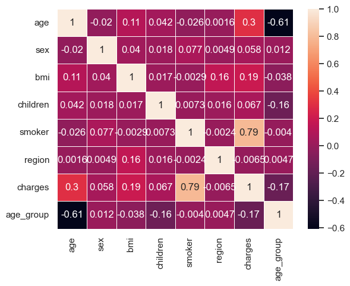

```python
#Showing Correlation between faetures and label
sns.heatmap(data.corr(),cbar=True,linewidth=0.5,annot=True)
plt.show()
```

#### Selecting Features

```python
#dropping age_group because it is unnecessary
x=data.drop(["charges","age_group"],axis=1)
y=data.charges
#showing shapes of feature and target
print(f"x shape: {x.shape}")
print(f"y shape: {y.shape}")
```

```
x shape: (1337, 6)
y shape: (1337,)
```

#### Splitting Data

```python
#importing splitting model
from sklearn.model_selection import train_test_split
```

```python
#splitting the dataste
X_train,X_test,y_train,y_test=train_test_split(x,y,test_size=0.2,random_state=100)
```

```python
#Displaying spit dataset shapes
print(f"X_test shape: {X_test.shape}")
print(f"X_train shape: {X_train.shape}")
print(f"y_test shape: {y_test.shape}")
print(f"y_train shape: {y_train.shape}")
```

```
X_test shape: (268, 6)
X_train shape: (1069, 6)
y_test shape: (268,)
y_train shape: (1069,)
```

### Creating Regresion model

#### Linear Regressor

```python
from sklearn.linear_model import LinearRegression
```

```python
#Training the model
Lr=LinearRegression()
Lr.fit(X_train,y_train)
```

```
LinearRegression()
```

```python
#Predicting y
Lr_y_Predict=Lr.predict(X_test)
```

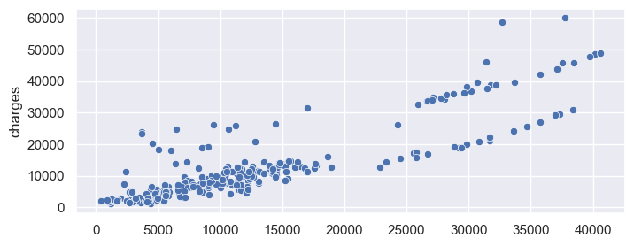

```python
#plotting Lr_y_Predict against y_test
sns.set_style("darkgrid")
plt.figure(figsize=(8,3))
sns.scatterplot(x=Lr_y_Predict,y=y_test)
plt.show()
```

#### Lr Model Equation

```python
#Lr Intercept and coeffcient
print(f"intercept: {Lr.intercept_}")
print(f"Coeficients: {Lr.coef_}")
```

```
intercept: -12140.51287613358
Coeficients: [ 2.66207205e+02 -1.98326402e+01  3.29188620e+02  4.77577548e+02
  2.35856245e+04 -2.73080750e+02]
```

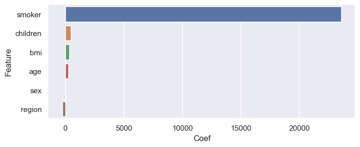

```python
# Diaplaying Feature Importance
D1={"Feature":X_train.columns,"Coef":Lr.coef_,}
Lr_importance=pd.DataFrame(D1)
Lr_Importance_Sorted=Lr_importance.sort_values(by="Coef",ascending=False)
plt.figure(figsize=(8,3))
sns.barplot(y="Feature",x="Coef",data=Lr_Importance_Sorted)
plt.show()
```

#### Lr Model Evaluation

```python
from sklearn import metrics
from sklearn.metrics import mean_absolute_percentage_error
```

```python
#Finding Mean Errors
Lr_mae=metrics.mean_absolute_error(y_test,Lr_y_Predict)
Lr_mape=metrics.mean_absolute_percentage_error(y_test,Lr_y_Predict)
Lr_mse=metrics.mean_squared_error(y_test,Lr_y_Predict)
Lr_rmse=np.sqrt(metrics.mean_squared_error(y_test,Lr_y_Predict))
Lr_r2=metrics.r2_score(y_test,Lr_y_Predict)
```

```python
#Displaying Mean errors and r2
print(f"Lr_mae: {Lr_mae}")
print(f"Lr_mape: {Lr_mape}")
print(f"Lr_mse: {Lr_mse}")
print(f"Lr_rmse: {Lr_rmse}")
print(f"Lr_r2: {Lr_r2}")
```

```
Lr_mae: 3973.414437998465
Lr_mape: 0.3707743118822404
Lr_mse: 33709951.02769122
Lr_rmse: 5806.027129431211
Lr_r2: 0.7513309072336347
```

### Creating Decision Tree Regressor

```python
from sklearn.tree import DecisionTreeRegressor
```

```python
#Training the model
Tr=DecisionTreeRegressor(random_state=42)
Tr.fit(X_train,y_train)
```

```
DecisionTreeRegressor(random_state=42)
```

```python
#Predicting y
Tr_y_Predict=Tr.predict(X_test)
```

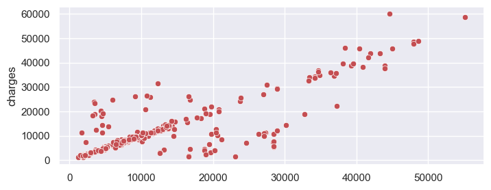

```python
#plotting Lr_y_Predict against y_test
plt.figure(figsize=(8,3))
sns.set_style("darkgrid")
sns.scatterplot(x=Tr_y_Predict,y=y_test,color="r")
plt.show()
```

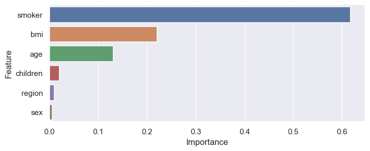

```python
#Displaying Feature Importance
Tr_importance=pd.DataFrame({"Feature":X_train.columns,"Importance":Tr.feature_importances_})
Tr_Sorted=Tr_importance.sort_values(by="Importance",ascending=False)
plt.figure(figsize=(8,3))
sns.barplot(y="Feature",x="Importance",data=Tr_Sorted)
plt.show()
```

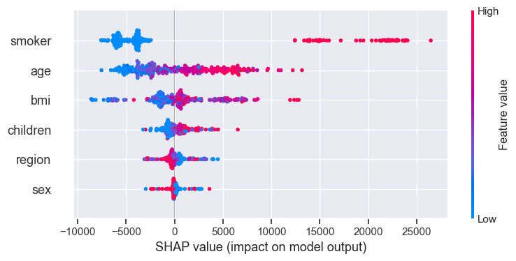

```python
#Plotting shap values
import shap
explainer=shap.TreeExplainer(Tr)
shap_values=explainer.shap_values(X_test)
shap.summary_plot(shap_values, X_test)
```

#### Tr Model Evaluation

```python
from sklearn import metrics
from sklearn.metrics import mean_absolute_percentage_error
```

```python
#Finding Mean Errors
Tr_mae=metrics.mean_absolute_error(y_test,Tr_y_Predict)
Tr_mape=metrics.mean_absolute_percentage_error(y_test,Tr_y_Predict)
Tr_mse=metrics.mean_squared_error(y_test,Tr_y_Predict)
Tr_rmse=np.sqrt(metrics.mean_squared_error(y_test,Tr_y_Predict))
Tr_r2=metrics.r2_score(y_test,Tr_y_Predict)
```

```python
#Displaying Mean errors and r2
print(f"Tr_mae: {Tr_mae}")
print(f"Tr_mape: {Tr_mape}")
print(f"Tr_mse: {Tr_mse}")
print(f"Tr_rmse: {Tr_rmse}")
print(f"Tr_r2: {Tr_r2}")
```

```
Tr_mae: 3588.6348089888065
Tr_mape: 0.4979702809548329
Tr_mse: 49537683.22372904
Tr_rmse: 7038.3011603460845
Tr_r2: 0.6345740539678268
```

### Creating Random Forest Regressor

```python
from sklearn.ensemble import RandomForestRegressor
```

```python
#Training the model
Rr=RandomForestRegressor(random_state=42)
Rr.fit(X_train,y_train)
```

```
RandomForestRegressor(random_state=42)
```

```python
#Predicting y
Rr_y_Predict=Rr.predict(X_test)
```

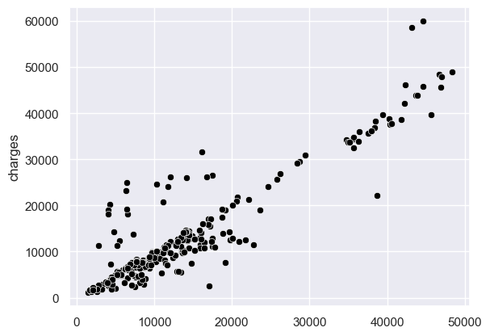

```python
#plotting Lr_y_Predict against y_test
sns.set_style("darkgrid")
sns.scatterplot(x=Rr_y_Predict,y=y_test,color="black")
plt.show()
```

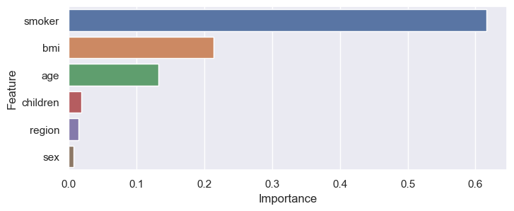

```python
#Displaying Feature Importance
Rr_importance=pd.DataFrame({"Feature":X_train.columns,"Importance":Rr.feature_importances_})
Rr_Sorted=Rr_importance.sort_values(by="Importance",ascending=False)
plt.figure(figsize=(8,3))
sns.barplot(y="Feature",x="Importance",data=Rr_Sorted)
plt.show()
```

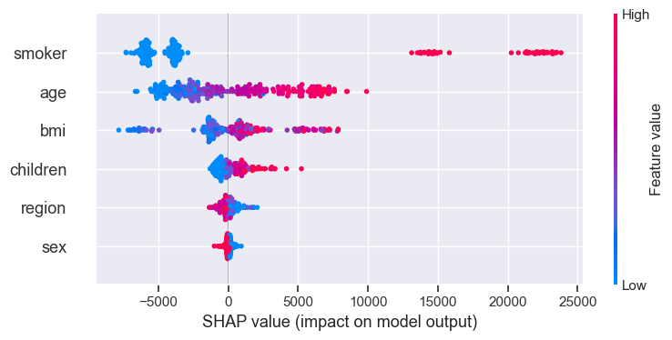

```python
#Plotting Shap values
import shap
explainer=shap.TreeExplainer(Rr)
shap_values=explainer.shap_values(X_test)
shap.summary_plot(shap_values, X_test)
```

#### Rr Model Evaluation

```python
from sklearn import metrics
from sklearn.metrics import mean_absolute_percentage_error
```

```python
#Finding Mean Errors
Rr_mae=metrics.mean_absolute_error(y_test,Rr_y_Predict)
Rr_mape=metrics.mean_absolute_percentage_error(y_test,Rr_y_Predict)
Rr_mse=metrics.mean_squared_error(y_test,Rr_y_Predict)
Rr_rmse=np.sqrt(metrics.mean_squared_error(y_test,Rr_y_Predict))
Rr_r2=metrics.r2_score(y_test,Rr_y_Predict)
```

```python
#Displaying Mean errors and r2
print(f"Rr_mae: {Rr_mae}")
print(f"Rr_mape: {Rr_mape}")
print(f"Rr_mse: {Rr_mse}")
print(f"Rr_rmse: {Rr_rmse}")
print(f"Rr_r2: {Rr_r2}")
```

```
Rr_mae: 2730.417412576027
Rr_mape: 0.30450448496657145
Rr_mse: 21864547.70173599
Rr_rmse: 4675.9542022710175
Rr_r2: 0.8387112091538987
```